# Exploring U.S. Policing Trends Through Data

May 13, 2025

Henok Dawite

## Project Overview

- I used public traffic stop data to explore disparities in policing.
- Focused on two things:
  1. How often people of different races are searched.
  2. What typically happens after someone is stopped.
- This was done using SQL and basic visual analysis.

## The Data

- From the Stanford Open Policing Project (50M+ stops).
- I looked at three NC cities (Charlotte, Raleigh, Greensboro) and Oakland, CA.
- Removed incomplete data to keep things clean and accurate.

## What I Looked At

- How search rates compare by race across three NC cities.
- What the overall outcomes are after stops in Oakland.
- Focus was on identifying patterns — not proving intent or causation.

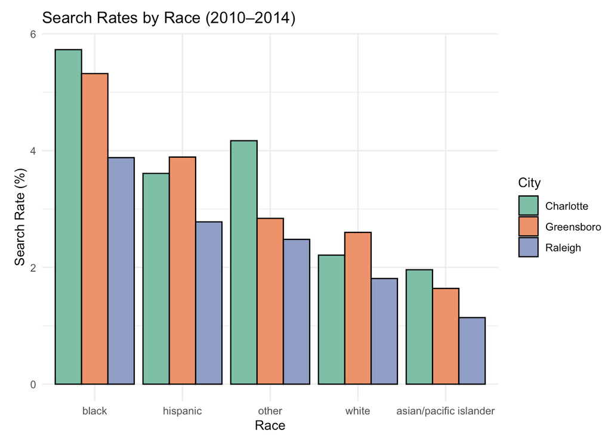

## Search Rate Results

[figure not shown]

## Stop Outcome Results

- In Oakland:
  - 52% of stops led to citations
  - 31% to warnings
  - 17% to arrests
- Most stops don’t end in arrest, but 1 in 6 still do — which stands out.

## What the Patterns Suggest

- The search data shows consistent gaps between racial groups.
- The outcome data shows how often enforcement escalates to arrest.
- Together, they highlight areas worth more attention and review.

## How I Did It

- I used SQL to group and filter the data.
- Focused on cities with full reporting to keep comparisons fair.
- The approach was simple, clean, and easy to trace.

## A Few Notes

- I didn’t analyze outcomes by race — just overall rates.
- Not every city had usable data, so I narrowed the scope.
- This project shows patterns — not causes.

## Final Takeaway

- The data shows real disparities in search rates across race.
- Simple analysis can bring out meaningful insights.
- Public data like this is a powerful tool for accountability.

## Citations

Pierson, E., Corbett-Davies, S., & Goel, S. (2020). A large-scale analysis of racial disparities in police stops across the United States. *Nature Human Behaviour*, 4(7), 736–745. https://doi.org/10.1038/s41562-020-0858-1

Data : Stanford Open Policing Project — https://openpolicing.stanford.edu/data/